# 3.1 Mobile Phone Picture

Samir Ibrahimov

2025-05-02

## Overview

The aim of this section is to reduce the number of RGB colors in a smartphone photo using K-means clustering. We’ll use the Elbow method to select the appropriate number of color clusters and evaluate how image detail changes with different k values. The image contains a paper with the name “SAMIR” and background elements to ensure a rich color palette.

## 1. Importing libraries

```r
# Load required packages
library(imager)
library(tidyverse)
library(reshape2)
```

imager is used for image handling, tidyverse for data manipulation, and reshape2 to help transform image data for clustering.

## 2. Loading and displaying the image

[figure not shown]

```r
# Load the resized image
img <- load.image("IMG_8170.jpg")

# Display the image
plot(img, main = "Original Resized Image (256x256)")
```

This verifies that the image was properly loaded.

## 3. Transforming Image into RGB Data Frame

To apply K-means, we need the image in a data frame where each row represents a pixel and columns represent the Red, Green, and Blue color channels. We extract and reshape this from the image object.

```r
# Convert image to data frame
img_df <- as.data.frame(img)

# Spread the color channels into separate columns
img_rgb <- img_df %>%
  select(x, y, cc, value) %>%
  spread(key = cc, value = value)

# Rename color columns for clarity
colnames(img_rgb) <- c("x", "y", "R", "G", "B")

# Keep only RGB values for clustering
rgb_data <- img_rgb[, c("R", "G", "B")]
```

Each pixel is originally stored in long format, where each RGB value is in a separate row. We reshape it to wide format so each row contains the full RGB information for one pixel. This clean RGB matrix is required input for K-means.

## 4. Determining the optimal number of clusters (Elbow method)

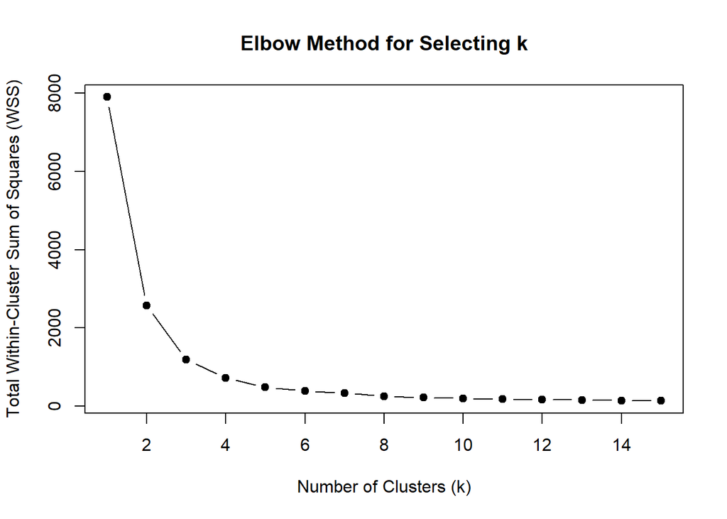

```r
# Set seed for reproducibility
set.seed(123)

# Compute WSS for k from 1 to 15
wss <- map_dbl(1:15, function(k) {
  kmeans(rgb_data, centers = k, nstart = 5)$tot.withinss
})

# Plot the Elbow Curve
plot(1:15, wss, type = "b", pch = 19,
     xlab = "Number of Clusters (k)",
     ylab = "Total Within-Cluster Sum of Squares (WSS)",
     main = "Elbow Method for Selecting k")
```

The elbow point is the value of k where the WSS curve bends and starts to flatten. This point suggests the optimal number of color clusters for compressing the image with minimal loss of detail. We see from the graph that k=4 is the optimal point for us.

## 5. Applying K-means clustering to the image

Now that we’ve selected k = 4 as the optimal number of clusters based on the elbow method, we apply K-means clustering to the RGB pixel values. Each pixel will be assigned to one of the four color groups, and its color will be replaced by the average color of that cluster.

```r
# Set k to 4 based on elbow result
k <- 4
set.seed(123)

# Apply k-means clustering
kmeans_result <- kmeans(rgb_data, centers = k, nstart = 5)

# Map each pixel to its cluster's centroid color
cluster_colors <- kmeans_result$centers[kmeans_result$cluster, ]

# Create a new data frame with clustered color values
img_compressed <- img_rgb
img_compressed$R <- cluster_colors[, "R"]
img_compressed$G <- cluster_colors[, "G"]
img_compressed$B <- cluster_colors[, "B"]
```

This step reduces the color palette of the original image from thousands of RGB combinations to just 4.

## 6. Reconstructing and displaying the final image

We’ll now rebuild the image from the clustered RGB values and plot the new image, which should visually resemble the original but with only 4 dominant colors.

[figure not shown]

```r
# Reshape each color vector back into a 256x256 matrix
R_channel <- as.cimg(matrix(img_compressed$R, 256, 256))
G_channel <- as.cimg(matrix(img_compressed$G, 256, 256))
B_channel <- as.cimg(matrix(img_compressed$B, 256, 256))

# Combine channels into one color image
img_kmeans <- imappend(list(R_channel, G_channel, B_channel), axis = "c")

# Plot the compressed image
plot(img_kmeans, main = "Image After K-Means Compression (k = 4)")
```

## 6b. Comparing with a higher k value (k=8)

To better understand the impact of color complexity, we re-run the K-means clustering with k = 8 and visualize the result.

[figure not shown]

```r
# Apply K-means clustering with k = 8
k_alt <- 8
set.seed(123)
kmeans_result_8 <- kmeans(rgb_data, centers = k_alt, nstart = 5)

# Map each pixel to its new cluster's centroid color
cluster_colors_8 <- kmeans_result_8$centers[kmeans_result_8$cluster, ]

# Build a new compressed image
img_compressed_8 <- img_rgb
img_compressed_8$R <- cluster_colors_8[, "R"]
img_compressed_8$G <- cluster_colors_8[, "G"]
img_compressed_8$B <- cluster_colors_8[, "B"]

# Reconstruct image from RGB channels
R8 <- as.cimg(matrix(img_compressed_8$R, 256, 256))
G8 <- as.cimg(matrix(img_compressed_8$G, 256, 256))
B8 <- as.cimg(matrix(img_compressed_8$B, 256, 256))
img_kmeans_8 <- imappend(list(R8, G8, B8), axis = "c")

# Plot the image with k = 8
plot(img_kmeans_8, main = "Image After K-Means Compression (k = 8)")
```

This version uses more color clusters, which increases the image’s richness and accuracy in color reproduction. Compared to the 4-color version, it captures smoother gradients and finer differences, such as the transition in shadows or reflections.

## 7. Conclusion

We applied K-means clustering to perform color quantization on a real-world image. The process involved reducing the number of unique RGB colors to a smaller set of representative colors to observe how color simplification affects image detail and clarity.

To explore the trade-off between compression and visual detail, we also experimented with k = 8. This version retained finer color transitions and provided a more faithful representation of areas like the drink can, cloth pouch, and paper edges.